# Case Study: How Does a Bike-Share Navigate Speedy Success?

#### Process and Analyze

Let's find the differences between Casual Group and Member Group of users

**Average and max ride duration**

```python
# members average duration
data_mem = trips_df[trips_df["member_casual"] == "member"]
data_mem_ride_dur_avg = data_mem["ride_duration"].mean()
data_mem_ride_dur_avg
```

```
Timedelta('0 days 00:13:02.626290436')
```

Total member average ride duration= 13 mins 02 secs

```python
# casuals average duration
data_cas = trips_df[trips_df["member_casual"] == "casual"]
data_cas_ride_dur_avg = data_cas["ride_duration"].mean()
data_cas_ride_dur_avg
```

```
Timedelta('0 days 00:30:32.885747133')
```

Total casual average ride duration= 30 mins 32 secs

```python
# members average ride duration per day of week
data_mem_ride_dur_pday = trips_df[trips_df["member_casual"] == "member"].groupby('weekday')['ride_duration'].mean()
data_mem_ride_dur_pday
```

```
weekday
0   0 days 00:12:38.709713890
1   0 days 00:12:16.712865872
2   0 days 00:12:18.501313805
3   0 days 00:12:26.564273330
4   0 days 00:12:46.933884441
5   0 days 00:14:37.410954990
6   0 days 00:14:47.440309492
Name: ride_duration, dtype: timedelta64[ns]
```

```python
# casuals average ride duration per day of week
data_cas_ride_dur_pday = trips_df[trips_df["member_casual"] == "casual"].groupby('weekday')['ride_duration'].mean()
data_cas_ride_dur_pday
```

```
weekday
0   0 days 00:30:31.655157459
1   0 days 00:26:14.501909261
2   0 days 00:26:39.369488156
3   0 days 00:27:42.442867141
4   0 days 00:28:46.740225325
5   0 days 00:33:30.353486583
6   0 days 00:35:20.327167819
Name: ride_duration, dtype: timedelta64[ns]
```

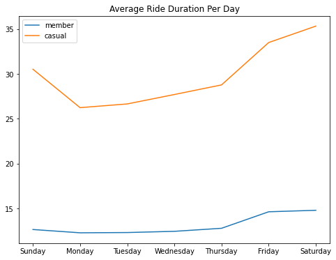

```python
# plotting above data
plt.figure(figsize=(8,6))
plt.plot(data_mem_ride_dur_pday/pd.Timedelta(minutes=1))
plt.plot(data_cas_ride_dur_pday/pd.Timedelta(minutes=1)) # getting average in minutes
plt.title("Average Ride Duration Per Day")
plt.legend(["member","casual"])
labels = ["Sunday","Monday","Tuesday","Wednesday","Thursday","Friday","Saturday"]
plt.xticks(data_mem_ride_dur_pday.index,labels)
plt.show()
```

So on an average, the casual group of users have longest duration of rides.

```python
# members max duration
data_mem_ride_dur_max = data_mem["ride_duration"].max()
data_mem_ride_dur_max
```

```
Timedelta('1 days 01:59:54')
```

```python
# casuals max duration
data_cas_ride_dur_max = data_cas["ride_duration"].max()
data_cas_ride_dur_max
```

```
Timedelta('38 days 20:24:09')
```

It seems casuals maximum is much higher than usual. We need to dig deeper to find out the reason.

**Day of week with most rides**

```python
# members
data_mem_ride_day_most = data_mem["weekday"].mode()
data_mem_ride_day_most
```

```
0    1
Name: weekday, dtype: int64
```

```python
# casuals
data_cas_ride_day_most = data_cas["weekday"].mode()
data_cas_ride_day_most
```

```
0    5
Name: weekday, dtype: int64
```

**Total number of rides**

```python
# total rides by members and casuals
mem_type_total = trips_df["member_casual"].value_counts()
mem_type_total
```

```
member    3300919
casual    2559857
Name: member_casual, dtype: int64
```

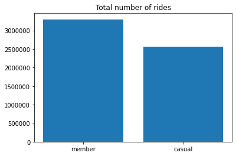

```python
# plotting above data
plt.title("Total number of rides")
plt.bar(mem_type_total.index, mem_type_total.values)
plt.ticklabel_format(style = 'plain', axis = 'y')
plt.show()
```

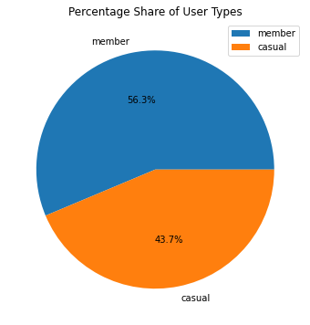

```python
# percentage share through a pie-chart
plt.figure(figsize = (8,6))
plt.pie(mem_type_total.values, labels = mem_type_total.index, autopct='%1.1f%%')
plt.title("Percentage Share of User Types")
plt.legend(mem_type_total.index)
plt.show()
```

```python
# member user rides total by day of week
mem_rides_pday= trips_df[trips_df["member_casual"]=="member"].groupby('weekday')['ride_id'].count()
mem_rides_pday
```

```
weekday
0    466116
1    524807
2    512633
3    501810
4    459801
5    441041
6    394711
Name: ride_id, dtype: int64
```

```python
# casual user rides total by day of week
cas_rides_pday = trips_df[trips_df["member_casual"] == "casual"].groupby('weekday')['ride_id'].count()
cas_rides_pday
```

```
weekday
0    302077
1    287022
2    285771
3    308614
4    360012
5    546165
6    470196
Name: ride_id, dtype: int64
```

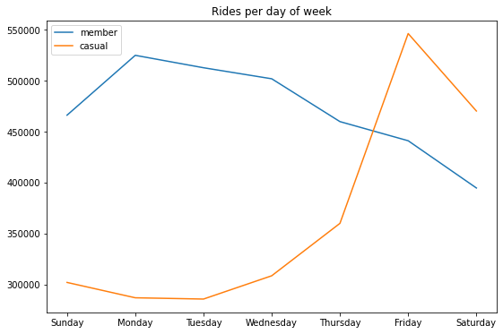

```python
# plotting above data
plt.figure(figsize = (9,6))
plt.plot(mem_rides_pday)
plt.plot(cas_rides_pday)
plt.title("Rides per day of week")
plt.legend(["member", "casual"])
labels=["Sunday", "Monday", "Tuesday", "Wednesday", "Thursday", "Friday", "Saturday"]
plt.xticks(mem_rides_pday.index, labels)
plt.show()
```

As we can see, member riders more in total and they tend to take rides on weekdays. Whereas, casual riders are more active riders on weekends. This insight will help us in planning promotional offers and advertisements targeted for weekend riders.

```python
# checking monthly trends
monthly_users = trips_df.groupby("month")['member_casual'].value_counts()
monthly_users
```

```
month  member_casual
1      member            85250
       casual            18520
2      member            94193
       casual            21416
3      member           194160
       casual            89882
4      member           244832
       casual           126417
5      member           354443
       casual           280415
6      casual           370681
       member           358914
7      casual           442056
       member           380354
8      casual           412671
       member           391681
9      member           392257
       casual           363890
10     member           373984
       casual           257242
11     member           253049
       casual           106929
12     member           177802
       casual            69738
Name: member_casual, dtype: int64
```

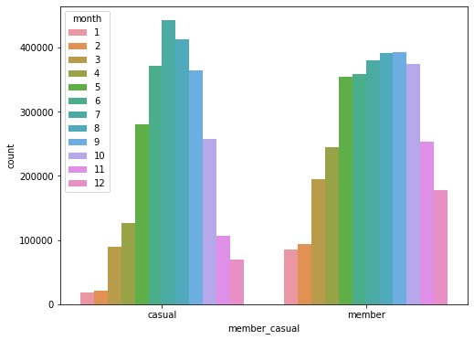

```python
# plotting above data
plt.figure(figsize = (8,6))
sns.countplot(x = "member_casual", hue="month", data = trips_df)
plt.show()
```

We can see that the riders increase from month of May through the summer. This could be because of good weather, summer break and holidays.

**Type of bikes used by members and casuals**

There are 3 types of bikes provided by the company. Let's have a look at what the riders prefer.

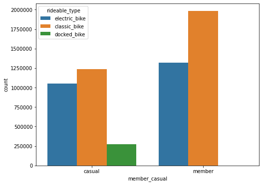

```python
plt.figure(figsize = (8,6))
sns.countplot(x = "member_casual", hue = "rideable_type", data = trips_df)
plt.ticklabel_format(style = 'plain', axis = 'y')
plt.show()
```

**Stations with highest riders (highest activity)**

```python
# top 10 start stations
pop_station_start = trips_df["start_station_name"].value_counts()
pop_station_start.head(10)
```

```
Streeter Dr & Grand Ave     84272
Wells St & Concord Ln       44080
Michigan Ave & Oak St       44010
Millennium Park             41276
Clark St & Elm St           40892
Wells St & Elm St           37556
Kingsbury St & Kinzie St    36107
Theater on the Lake         35949
Clark St & Armitage Ave     33047
Wabash Ave & Grand Ave      32986
Name: start_station_name, dtype: int64
```

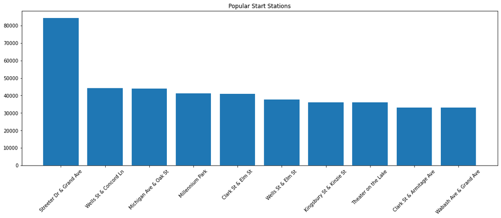

```python
plt.figure(figsize = (18,6))
plt.title("Popular Start Stations")
plt.bar(pop_station_start.head(10).index, pop_station_start.head(10).values)
plt.ticklabel_format(style = 'plain', axis = 'y')
plt.xticks(rotation = 45)
plt.show()
```

```python
# top 10 end stations
pop_station_end = trips_df["end_station_name"].value_counts()
pop_station_end.head(10)
```

```
Streeter Dr & Grand Ave               84764
Michigan Ave & Oak St                 44432
Wells St & Concord Ln                 44063
Millennium Park                       41692
Clark St & Elm St                     40012
Wells St & Elm St                     36937
Theater on the Lake                   36046
DuSable Lake Shore Dr & North Blvd    35808
Kingsbury St & Kinzie St              35148
Wabash Ave & Grand Ave                32887
Name: end_station_name, dtype: int64
```

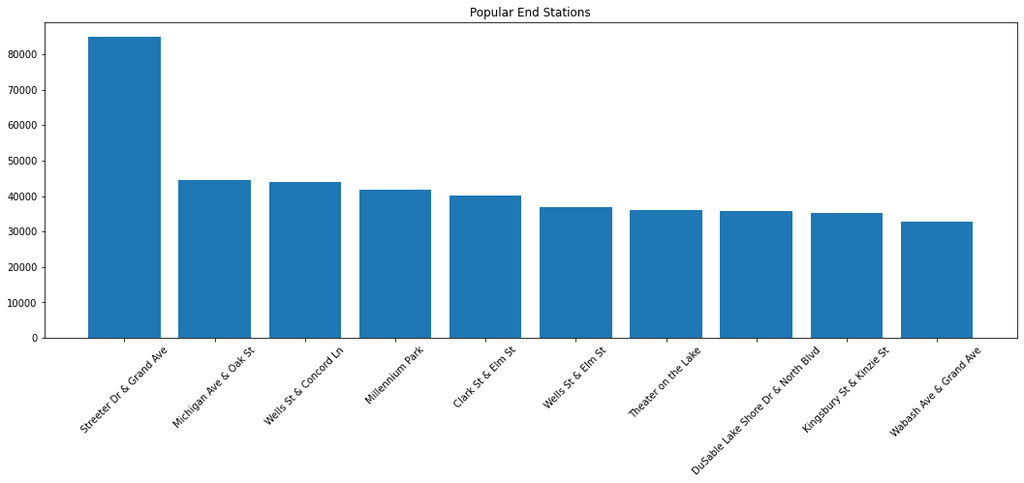

```python
plt.figure(figsize = (18,6))
plt.title("Popular End Stations")
plt.bar(pop_station_end.head(10).index, pop_station_end.head(10).values)
plt.ticklabel_format(style = 'plain', axis = 'y')
plt.xticks(rotation = 45)
plt.show()
```

From the above data we get an idea of which stations have high activity. This data could be useful in targeted campaigns by marketing team

#### Recap

Finally, we will do a recap of the findings before proceeding for recommendations

1) There's a large share of casual riders to be addressed 2) We found the trends between the 2 rider types like 1) Weekly and monthly riding habits 2) Duration of their rides 3) Type of bike preference 3) Stations with most activity i.e. popular stations

### Recommendations

1) Marketing campaign offering membership offers should focus on most popular stations and be during:

```
a) the busiest casual riders days i.e. during weekends and
b) the busiest months of the year i.e. during summer
```

2) Weekend discounts can be introduced to the member riders to increase their activity during weekends and will also be lucrative deal for casual members who prefer riding on weekends

3) Dockers can be on discounted rate for members as they are currently only used by casual riders. This will attract casual members who prefer dockers to consider membership